# Ally Auto Receivables Monthly Update

GMB Capital

Report generated: April 10, 2020

*Automated web-scraping, analysis and report generation via AWS/R/Github deployment pipeline. See technical overview at https://github.com/moman822/auto-abs/tree/gh-pages/10-d.*

### Summary statistics

**Issuer**: Ally Auto Receivables

**Most recent period**: 2020-02-01

**Number of active issuances**: 12

**Outstanding principal balance across all issuances**: $5,187,784,272

### Links to new reports

|  | deal | link | period |
| --- | --- | --- | --- |
| 1 | Ally Auto Receivables Trust 2017-1 | Report link | 2020-02-01 |
| 2 | Ally Auto Receivables Trust 2017-2 | Report link | 2020-02-01 |
| 3 | Ally Auto Receivables Trust 2017-3 | Report link | 2020-02-01 |
| 4 | Ally Auto Receivables Trust 2017-4 | Report link | 2020-02-01 |
| 5 | Ally Auto Receivables Trust 2017-5 | Report link | 2020-02-01 |
| 6 | Ally Auto Receivables Trust 2018-1 | Report link | 2020-02-01 |
| 7 | Ally Auto Receivables Trust 2018-2 | Report link | 2020-02-01 |
| 8 | Ally Auto Receivables Trust 2018-3 | Report link | 2020-02-01 |
| 9 | Ally Auto Receivables Trust 2019-1 | Report link | 2020-02-01 |
| 10 | Ally Auto Receivables Trust 2019-2 | Report link | 2020-02-01 |

[output cut: 2 more lines]

### Deal-level data

#### Ally Auto Receivables Trust 2017-1

##### Summary

Ending number of receivables: 24,671

Remaining principal balance across all receivables: $164,978,593

##### Current Period Distribution

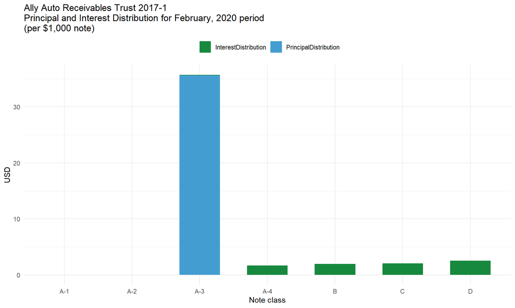

|  | deal | class | PrincipalDistribution | InterestDistribution |
| --- | --- | --- | --- | --- |
| 1 | Ally Auto Receivables Trust 2017-1 | A-1 | 0 | 0 |
| 2 | Ally Auto Receivables Trust 2017-1 | A-2 | 0 | 0 |
| 3 | Ally Auto Receivables Trust 2017-1 | A-3 | 35.562929631728 | 0.126161416430595 |
| 4 | Ally Auto Receivables Trust 2017-1 | A-4 | 0 | 1.65833333333333 |
| 5 | Ally Auto Receivables Trust 2017-1 | B | 0 | 1.95833347547974 |
| 6 | Ally Auto Receivables Trust 2017-1 | C | 0 | 2.06666683725691 |
| 7 | Ally Auto Receivables Trust 2017-1 | D | 0 | 2.51666666666667 |

##### Cumulative Distribution

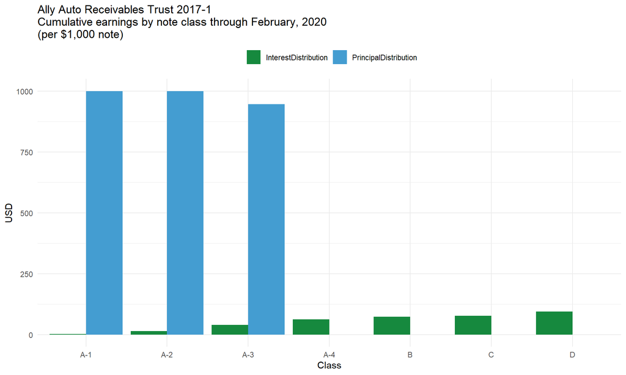

|  | deal | class | PrincipalDistribution | InterestDistribution |
| --- | --- | --- | --- | --- |
| 1 | Ally Auto Receivables Trust 2017-1 | A-1 | 1000 | 2.42697193430657 |
| 2 | Ally Auto Receivables Trust 2017-1 | A-2 | 1000 | 14.8860388385269 |
| 3 | Ally Auto Receivables Trust 2017-1 | A-3 | 946.507806232295 | 39.9702153824363 |
| 4 | Ally Auto Receivables Trust 2017-1 | A-4 | 0 | 62.1875000675037 |
| 5 | Ally Auto Receivables Trust 2017-1 | B | 0 | 73.4375053304904 |
| 6 | Ally Auto Receivables Trust 2017-1 | C | 0 | 77.5000061412487 |
| 7 | Ally Auto Receivables Trust 2017-1 | D | 0 | 94.375 |

##### Forecast

Forecasted principal balances are based on a forecasted total amount distributed to interest and principal balances in future terms. These values are calculated using an ETS time series forecasting model. It uses the historic values as input to create the forecasted values (see bottom chart).

Remaining note principal balances are calculated in each period by subtracting the forecasted dsitribution amount from remaining note principal balances according to note seniority. In each period, the interest distribution amount is first calculated and subtracted from the forecasted distribution amount before applying the remaining distribution amount to the note principal balances for the next period.

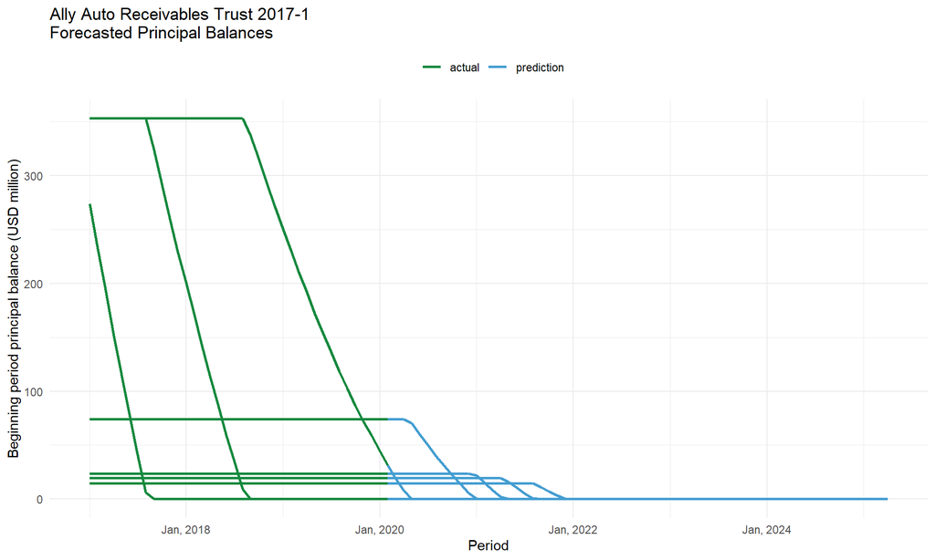

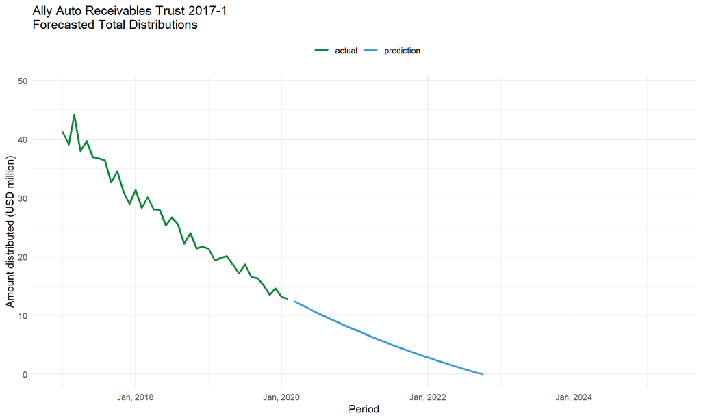

#### Ally Auto Receivables Trust 2017-2

##### Summary

Ending number of receivables: 24,247

Remaining principal balance across all receivables: $171,603,253

##### Current Period Distribution

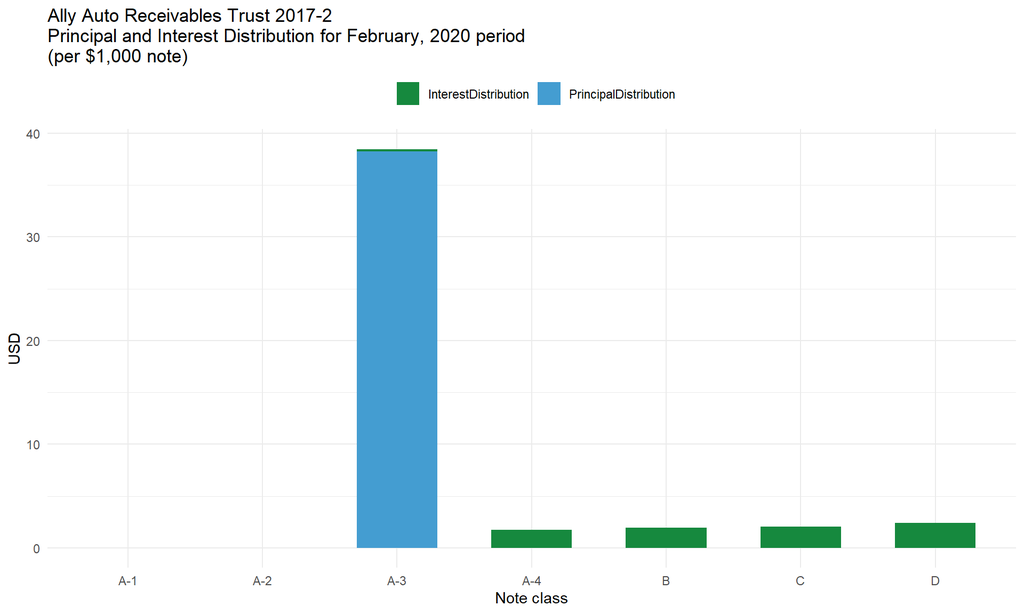

|  | deal | class | PrincipalDistribution | InterestDistribution |
| --- | --- | --- | --- | --- |
| 1 | Ally Auto Receivables Trust 2017-2 | A-1 | 0 | 0 |
| 2 | Ally Auto Receivables Trust 2017-2 | A-2 | 0 | 0 |
| 3 | Ally Auto Receivables Trust 2017-2 | A-3 | 38.2422992698423 | 0.224649208205582 |
| 4 | Ally Auto Receivables Trust 2017-2 | A-4 | 0 | 1.75 |
| 5 | Ally Auto Receivables Trust 2017-2 | B | 0 | 1.94166666666667 |
| 6 | Ally Auto Receivables Trust 2017-2 | C | 0 | 2.05 |
| 7 | Ally Auto Receivables Trust 2017-2 | D | 0 | 2.44166666666667 |

##### Cumulative Distribution

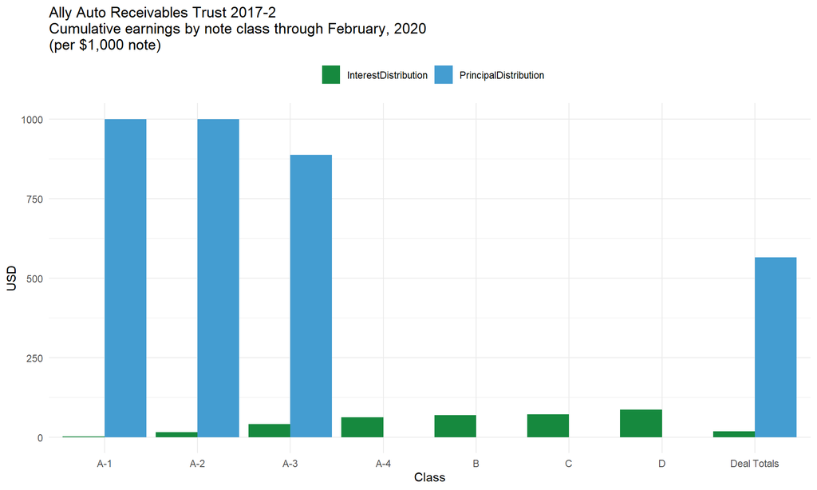

|  | deal | class | PrincipalDistribution | InterestDistribution |
| --- | --- | --- | --- | --- |
| 1 | Ally Auto Receivables Trust 2017-2 | A-1 | 1000 | 3.10794023076923 |
| 2 | Ally Auto Receivables Trust 2017-2 | A-2 | 1000 | 15.9186574264311 |
| 3 | Ally Auto Receivables Trust 2017-2 | A-3 | 886.793397129943 | 41.131348737238 |
| 4 | Ally Auto Receivables Trust 2017-2 | A-4 | 0 | 62.1833332857143 |
| 5 | Ally Auto Receivables Trust 2017-2 | B | 0 | 68.9938888888889 |
| 6 | Ally Auto Receivables Trust 2017-2 | C | 0 | 72.8433333333333 |
| 7 | Ally Auto Receivables Trust 2017-2 | D | 0 | 86.7605558069382 |

##### Forecast

Forecasted principal balances are based on a forecasted total amount distributed to interest and principal balances in future terms. These values are calculated using an ETS time series forecasting model. It uses the historic values as input to create the forecasted values (see bottom chart).

Remaining note principal balances are calculated in each period by subtracting the forecasted dsitribution amount from remaining note principal balances according to note seniority. In each period, the interest distribution amount is first calculated and subtracted from the forecasted distribution amount before applying the remaining distribution amount to the note principal balances for the next period.

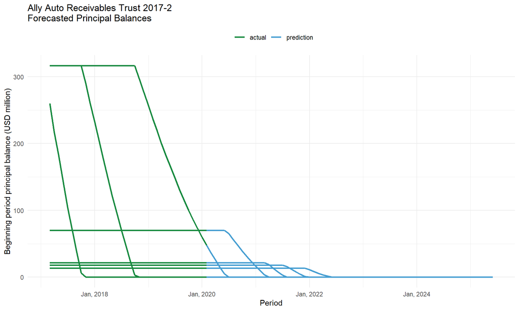

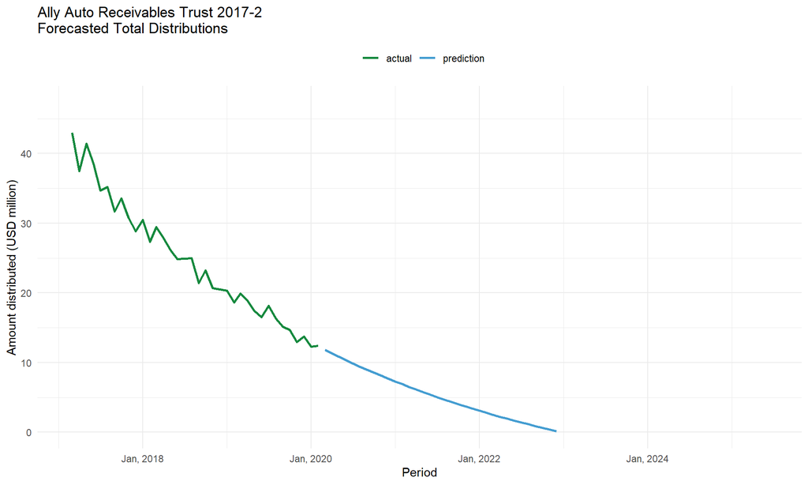

#### Ally Auto Receivables Trust 2017-3

##### Summary

Ending number of receivables: 25,836

Remaining principal balance across all receivables: $198,630,758

##### Current Period Distribution

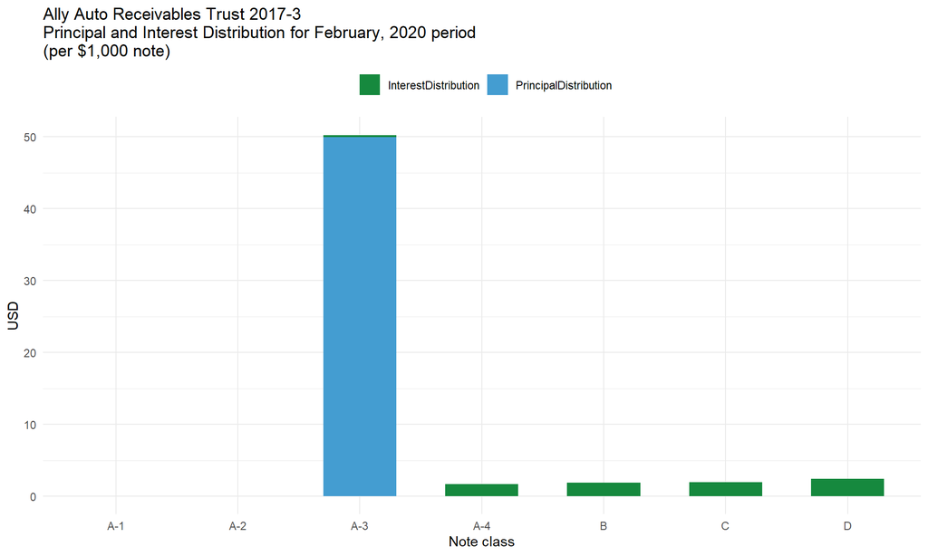

|  | deal | class | PrincipalDistribution | InterestDistribution |
| --- | --- | --- | --- | --- |
| 1 | Ally Auto Receivables Trust 2017-3 | A-1 | 0 | 0 |
| 2 | Ally Auto Receivables Trust 2017-3 | A-2 | 0 | 0 |
| 3 | Ally Auto Receivables Trust 2017-3 | A-3 | 49.9262321185098 | 0.309563068872757 |
| 4 | Ally Auto Receivables Trust 2017-3 | A-4 | 0 | 1.675 |
| 5 | Ally Auto Receivables Trust 2017-3 | B | 0 | 1.86666651665167 |
| 6 | Ally Auto Receivables Trust 2017-3 | C | 0 | 1.975 |
| 7 | Ally Auto Receivables Trust 2017-3 | D | 0 | 2.425 |

##### Cumulative Distribution

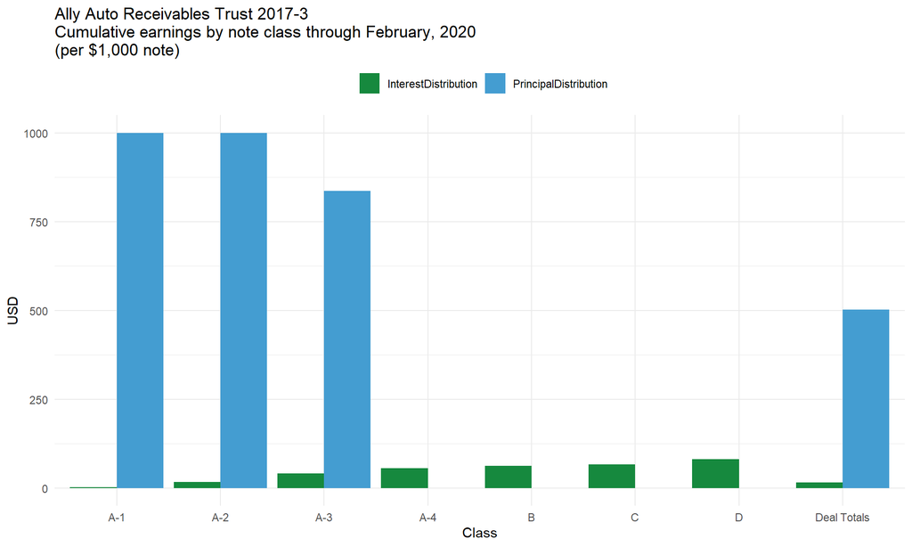

|  | deal | class | PrincipalDistribution | InterestDistribution |
| --- | --- | --- | --- | --- |
| 1 | Ally Auto Receivables Trust 2017-3 | A-1 | 1000 | 3.34578585185185 |
| 2 | Ally Auto Receivables Trust 2017-3 | A-2 | 1000 | 17.4705366076958 |
| 3 | Ally Auto Receivables Trust 2017-3 | A-3 | 836.434452334451 | 40.8678035523455 |
| 4 | Ally Auto Receivables Trust 2017-3 | A-4 | 0 | 56.4475000581328 |
| 5 | Ally Auto Receivables Trust 2017-3 | B | 0 | 62.9066615661566 |
| 6 | Ally Auto Receivables Trust 2017-3 | C | 0 | 66.5575002701243 |
| 7 | Ally Auto Receivables Trust 2017-3 | D | 0 | 81.7225003636364 |

##### Forecast

Forecasted principal balances are based on a forecasted total amount distributed to interest and principal balances in future terms. These values are calculated using an ETS time series forecasting model. It uses the historic values as input to create the forecasted values (see bottom chart).

Remaining note principal balances are calculated in each period by subtracting the forecasted dsitribution amount from remaining note principal balances according to note seniority. In each period, the interest distribution amount is first calculated and subtracted from the forecasted distribution amount before applying the remaining distribution amount to the note principal balances for the next period.

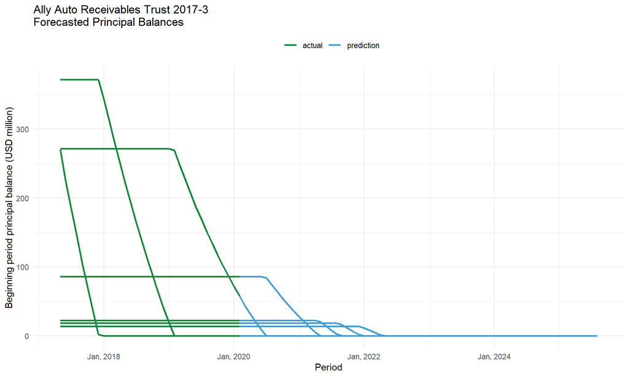

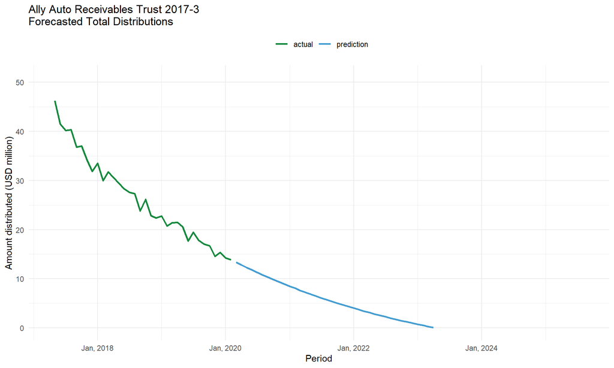

#### Ally Auto Receivables Trust 2017-4

##### Summary

Ending number of receivables: 31,452

Remaining principal balance across all receivables: $263,042,521

##### Current Period Distribution

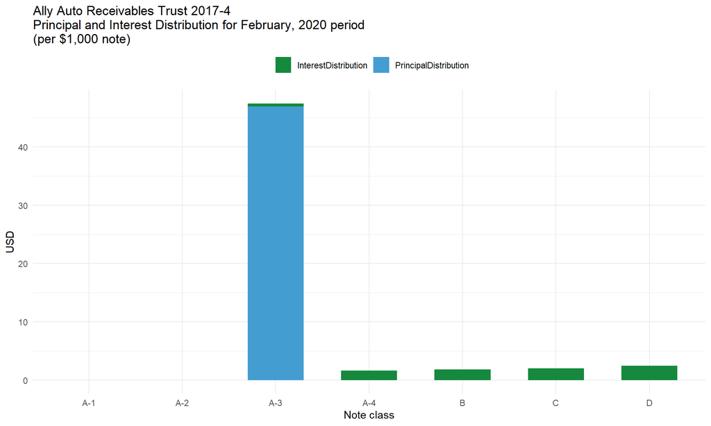

|  | deal | class | PrincipalDistribution | InterestDistribution |
| --- | --- | --- | --- | --- |
| 1 | Ally Auto Receivables Trust 2017-4 | A-1 | 0 | 0 |
| 2 | Ally Auto Receivables Trust 2017-4 | A-2 | 0 | 0 |
| 3 | Ally Auto Receivables Trust 2017-4 | A-3 | 46.9240897329377 | 0.500090118694362 |
| 4 | Ally Auto Receivables Trust 2017-4 | A-4 | 0 | 1.63333333333333 |
| 5 | Ally Auto Receivables Trust 2017-4 | B | 0 | 1.85833347657929 |
| 6 | Ally Auto Receivables Trust 2017-4 | C | 0 | 2.025 |
| 7 | Ally Auto Receivables Trust 2017-4 | D | 0 | 2.44166666666667 |

##### Cumulative Distribution

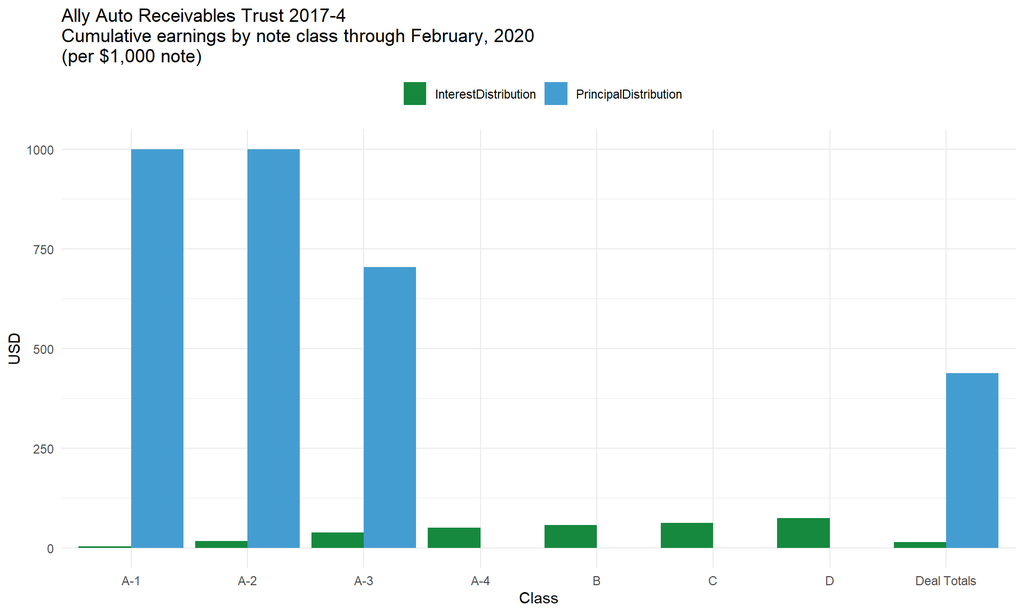

|  | deal | class | PrincipalDistribution | InterestDistribution |
| --- | --- | --- | --- | --- |
| 1 | Ally Auto Receivables Trust 2017-4 | A-1 | 1000 | 4.32772564285714 |
| 2 | Ally Auto Receivables Trust 2017-4 | A-2 | 1000 | 17.3812291691395 |
| 3 | Ally Auto Receivables Trust 2017-4 | A-3 | 704.005158664688 | 38.8505834124629 |
| 4 | Ally Auto Receivables Trust 2017-4 | A-4 | 0 | 50.1977777414788 |
| 5 | Ally Auto Receivables Trust 2017-4 | B | 0 | 57.112782122905 |
| 6 | Ally Auto Receivables Trust 2017-4 | C | 0 | 62.235 |
| 7 | Ally Auto Receivables Trust 2017-4 | D | 0 | 75.0405555555556 |

##### Forecast

Forecasted principal balances are based on a forecasted total amount distributed to interest and principal balances in future terms. These values are calculated using an ETS time series forecasting model. It uses the historic values as input to create the forecasted values (see bottom chart).

Remaining note principal balances are calculated in each period by subtracting the forecasted dsitribution amount from remaining note principal balances according to note seniority. In each period, the interest distribution amount is first calculated and subtracted from the forecasted distribution amount before applying the remaining distribution amount to the note principal balances for the next period.

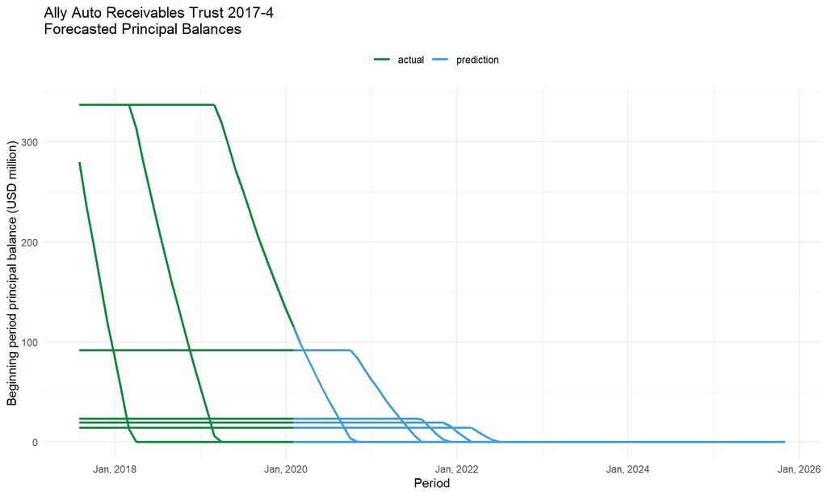

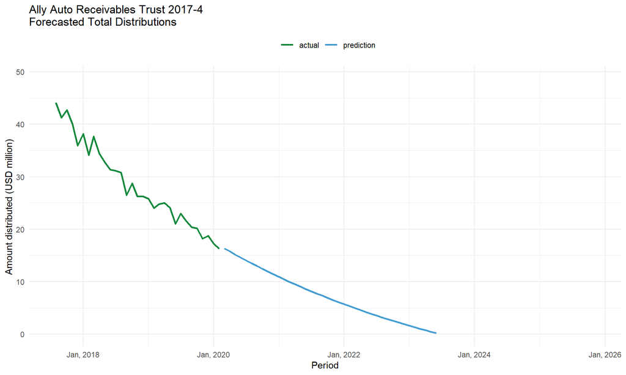

#### Ally Auto Receivables Trust 2017-5

##### Summary

Ending number of receivables: 16,663

Remaining principal balance across all receivables: $151,109,585

##### Current Period Distribution

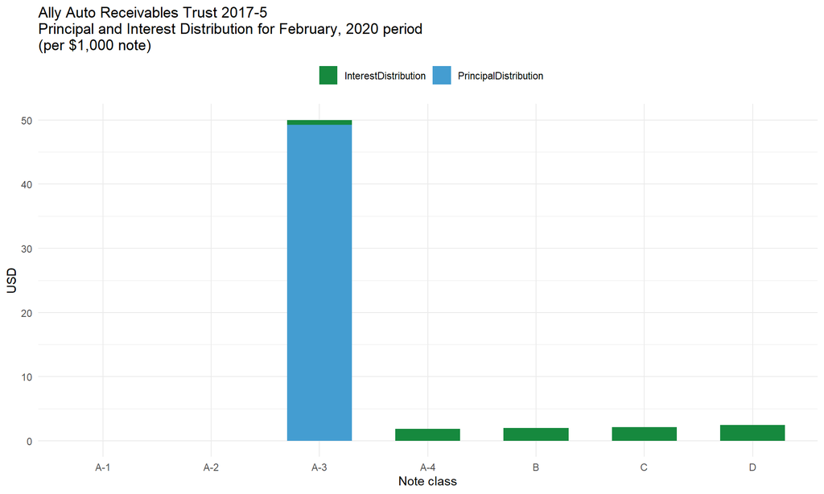

|  | deal | class | PrincipalDistribution | InterestDistribution |
| --- | --- | --- | --- | --- |
| 1 | Ally Auto Receivables Trust 2017-5 | A-1 | 0 | 0 |
| 2 | Ally Auto Receivables Trust 2017-5 | A-2 | 0 | 0 |
| 3 | Ally Auto Receivables Trust 2017-5 | A-3 | 49.2449027647059 | 0.748408 |
| 4 | Ally Auto Receivables Trust 2017-5 | A-4 | 0 | 1.85 |
| 5 | Ally Auto Receivables Trust 2017-5 | B | 0 | 2 |
| 6 | Ally Auto Receivables Trust 2017-5 | C | 0 | 2.11666632653061 |
| 7 | Ally Auto Receivables Trust 2017-5 | D | 0 | 2.49166620879121 |

##### Cumulative Distribution

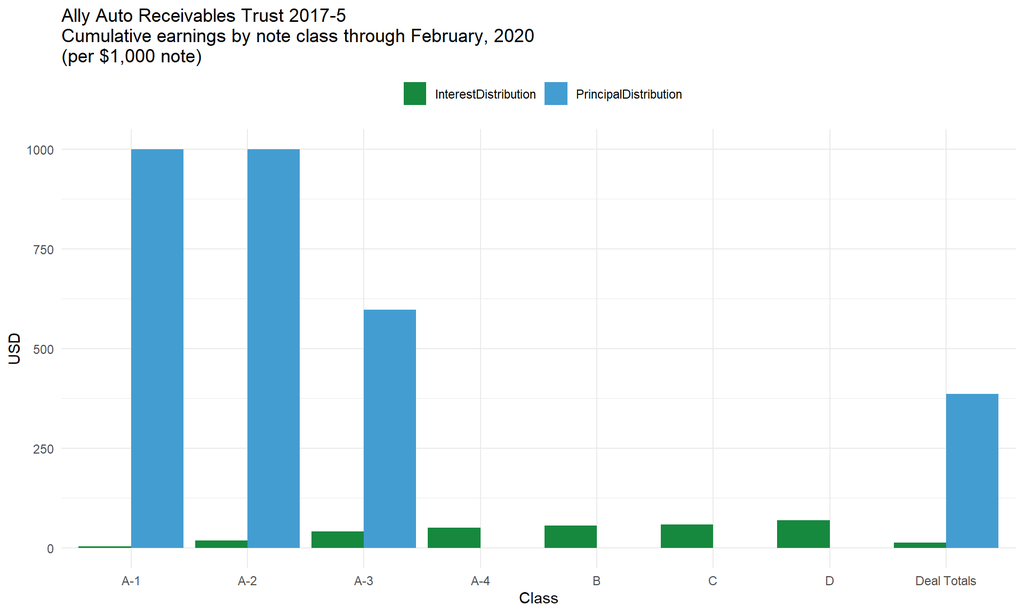

|  | deal | class | PrincipalDistribution | InterestDistribution |
| --- | --- | --- | --- | --- |
| 1 | Ally Auto Receivables Trust 2017-5 | A-1 | 1000 | 3.54158774647887 |
| 2 | Ally Auto Receivables Trust 2017-5 | A-2 | 1000 | 18.4459523529412 |
| 3 | Ally Auto Receivables Trust 2017-5 | A-3 | 597.943613117647 | 41.3828624705882 |
| 4 | Ally Auto Receivables Trust 2017-5 | A-4 | 0 | 51.3683334048027 |
| 5 | Ally Auto Receivables Trust 2017-5 | B | 0 | 55.5333333333333 |
| 6 | Ally Auto Receivables Trust 2017-5 | C | 0 | 58.7727683673469 |
| 7 | Ally Auto Receivables Trust 2017-5 | D | 0 | 69.1852651098901 |

##### Forecast

Forecasted principal balances are based on a forecasted total amount distributed to interest and principal balances in future terms. These values are calculated using an ETS time series forecasting model. It uses the historic values as input to create the forecasted values (see bottom chart).

Remaining note principal balances are calculated in each period by subtracting the forecasted dsitribution amount from remaining note principal balances according to note seniority. In each period, the interest distribution amount is first calculated and subtracted from the forecasted distribution amount before applying the remaining distribution amount to the note principal balances for the next period.

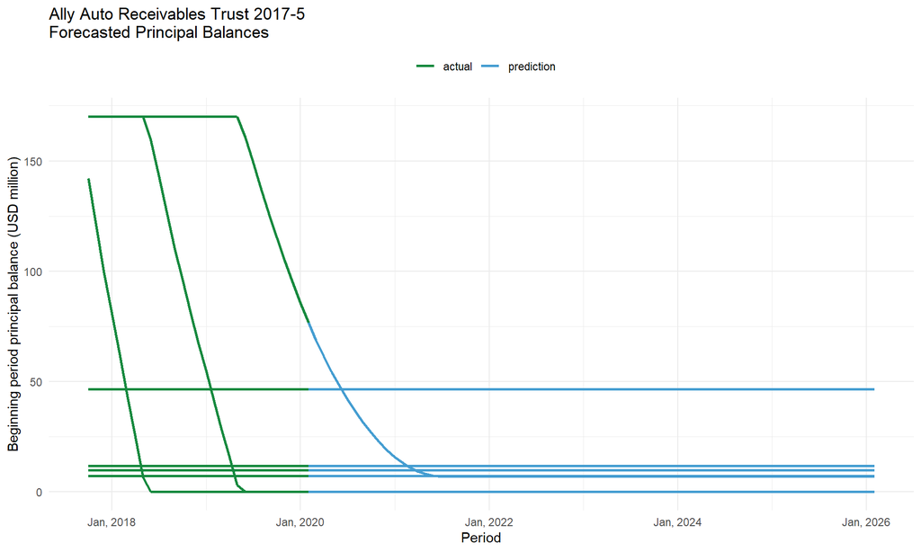

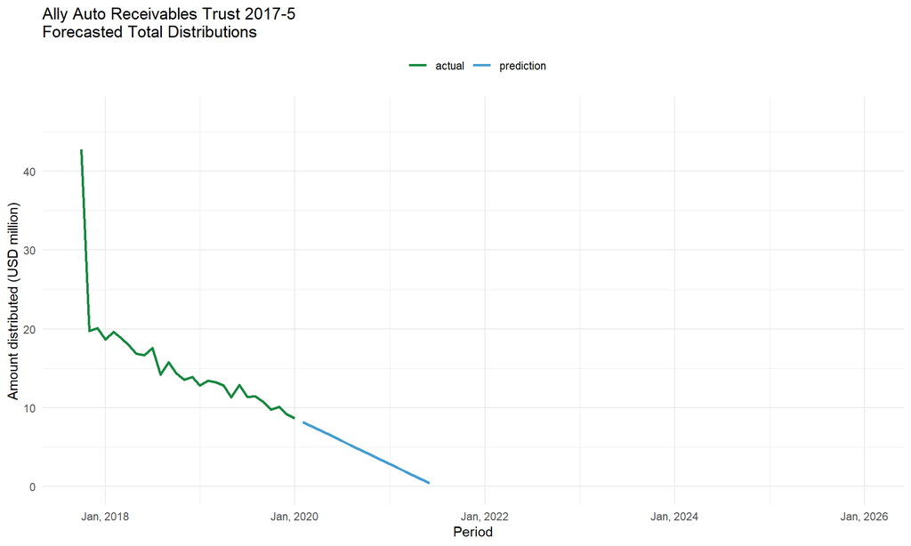

#### Ally Auto Receivables Trust 2018-1

##### Summary

Ending number of receivables: 35,583

Remaining principal balance across all receivables: $354,246,016

##### Current Period Distribution

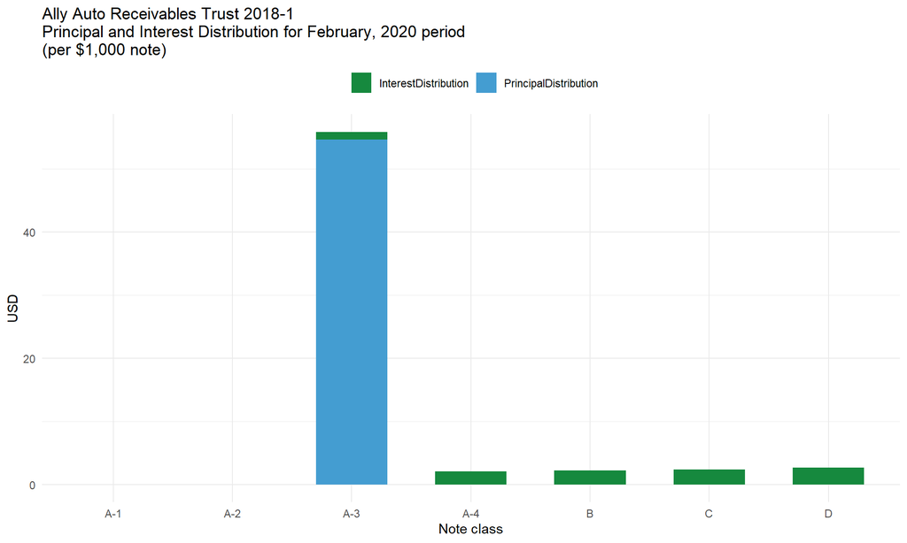

|  | deal | class | PrincipalDistribution | InterestDistribution |
| --- | --- | --- | --- | --- |
| 1 | Ally Auto Receivables Trust 2018-1 | A-1 | 0 | 0 |
| 2 | Ally Auto Receivables Trust 2018-1 | A-2 | 0 | 0 |
| 3 | Ally Auto Receivables Trust 2018-1 | A-3 | 54.6701884411765 | 1.18955402941176 |
| 4 | Ally Auto Receivables Trust 2018-1 | A-4 | 0 | 2.10833336876794 |
| 5 | Ally Auto Receivables Trust 2018-1 | B | 0 | 2.21666666666667 |
| 6 | Ally Auto Receivables Trust 2018-1 | C | 0 | 2.35833316326531 |
| 7 | Ally Auto Receivables Trust 2018-1 | D | 0 | 2.6833331043956 |

##### Cumulative Distribution

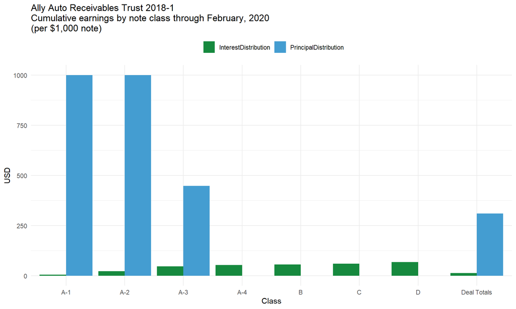

|  | deal | class | PrincipalDistribution | InterestDistribution |
| --- | --- | --- | --- | --- |
| 1 | Ally Auto Receivables Trust 2018-1 | A-1 | 1000 | 4.91968869257951 |
| 2 | Ally Auto Receivables Trust 2018-1 | A-2 | 1000 | 22.5550787058824 |
| 3 | Ally Auto Receivables Trust 2018-1 | A-3 | 447.238349705882 | 47.1113292352941 |
| 4 | Ally Auto Receivables Trust 2018-1 | A-4 | 0 | 53.7625009035824 |
| 5 | Ally Auto Receivables Trust 2018-1 | B | 0 | 56.525 |
| 6 | Ally Auto Receivables Trust 2018-1 | C | 0 | 60.1374959183673 |
| 7 | Ally Auto Receivables Trust 2018-1 | D | 0 | 68.4249945054945 |

##### Forecast

Forecasted principal balances are based on a forecasted total amount distributed to interest and principal balances in future terms. These values are calculated using an ETS time series forecasting model. It uses the historic values as input to create the forecasted values (see bottom chart).

Remaining note principal balances are calculated in each period by subtracting the forecasted dsitribution amount from remaining note principal balances according to note seniority. In each period, the interest distribution amount is first calculated and subtracted from the forecasted distribution amount before applying the remaining distribution amount to the note principal balances for the next period.

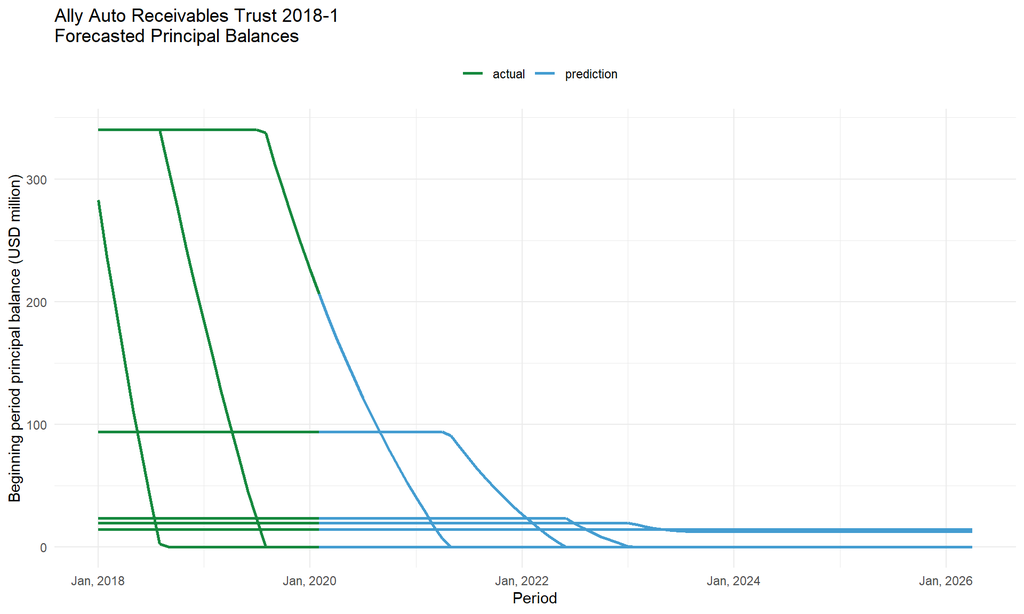

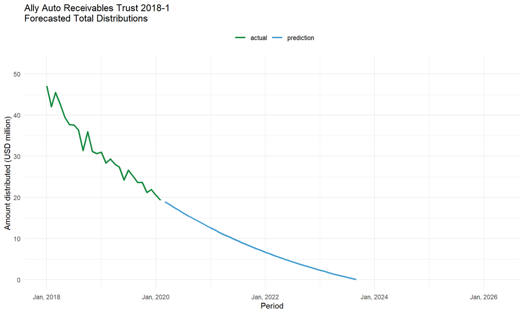

#### Ally Auto Receivables Trust 2018-2

##### Summary

Ending number of receivables: 38,671

Remaining principal balance across all receivables: $411,566,580

##### Current Period Distribution

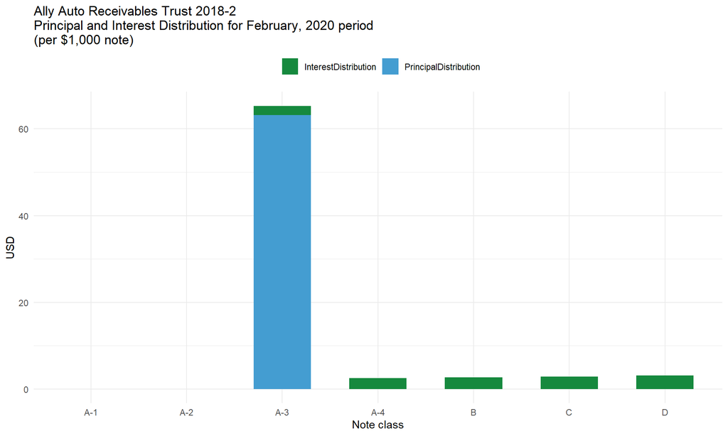

|  | deal | class | PrincipalDistribution | InterestDistribution |
| --- | --- | --- | --- | --- |
| 1 | Ally Auto Receivables Trust 2018-2 | A-1 | 0 | 0 |
| 2 | Ally Auto Receivables Trust 2018-2 | A-2 | 0 | 0 |
| 3 | Ally Auto Receivables Trust 2018-2 | A-3 | 63.1552234502346 | 2.14006946159546 |
| 4 | Ally Auto Receivables Trust 2018-2 | A-4 | 0 | 2.575 |
| 5 | Ally Auto Receivables Trust 2018-2 | B | 0 | 2.7 |
| 6 | Ally Auto Receivables Trust 2018-2 | C | 0 | 2.85833333333333 |
| 7 | Ally Auto Receivables Trust 2018-2 | D | 0 | 3.15 |

##### Cumulative Distribution

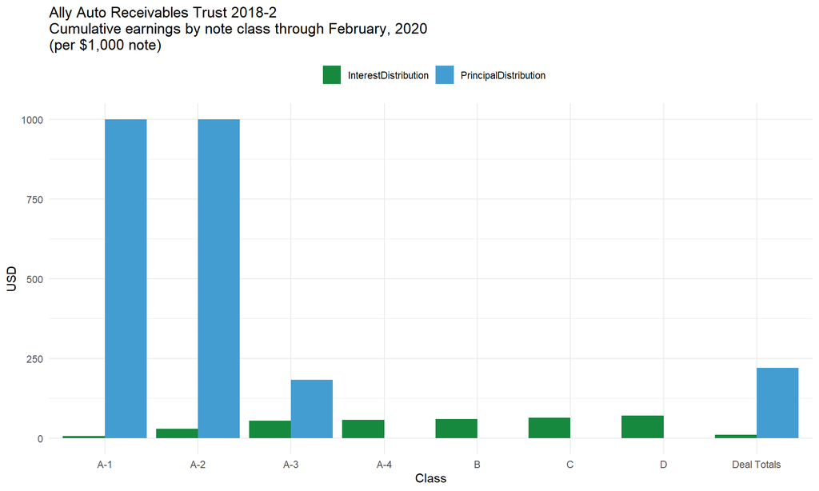

|  | deal | class | PrincipalDistribution | InterestDistribution |
| --- | --- | --- | --- | --- |
| 1 | Ally Auto Receivables Trust 2018-2 | A-1 | 1000 | 6.61381890459364 |
| 2 | Ally Auto Receivables Trust 2018-2 | A-2 | 1000 | 29.1118648908858 |
| 3 | Ally Auto Receivables Trust 2018-2 | A-3 | 183.674622437639 | 54.3217332674734 |
| 4 | Ally Auto Receivables Trust 2018-2 | A-4 | 0 | 57.9375 |
| 5 | Ally Auto Receivables Trust 2018-2 | B | 0 | 60.75 |
| 6 | Ally Auto Receivables Trust 2018-2 | C | 0 | 64.3125 |
| 7 | Ally Auto Receivables Trust 2018-2 | D | 0 | 70.875 |

##### Forecast

Forecasted principal balances are based on a forecasted total amount distributed to interest and principal balances in future terms. These values are calculated using an ETS time series forecasting model. It uses the historic values as input to create the forecasted values (see bottom chart).

Remaining note principal balances are calculated in each period by subtracting the forecasted dsitribution amount from remaining note principal balances according to note seniority. In each period, the interest distribution amount is first calculated and subtracted from the forecasted distribution amount before applying the remaining distribution amount to the note principal balances for the next period.

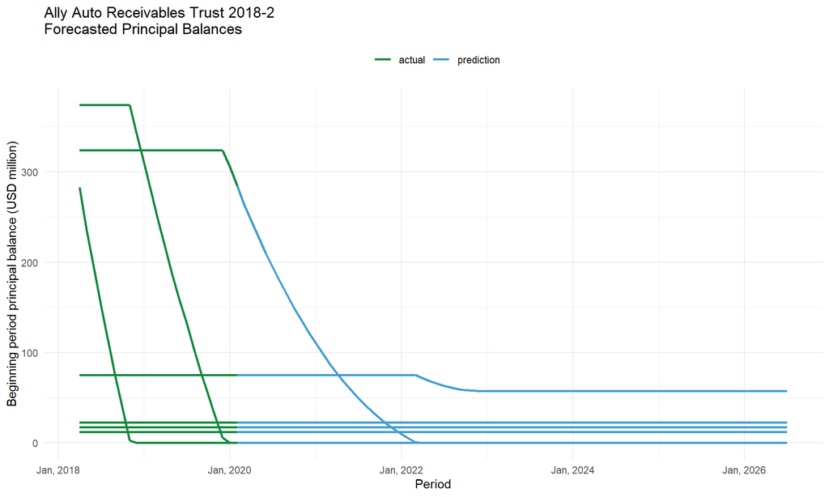

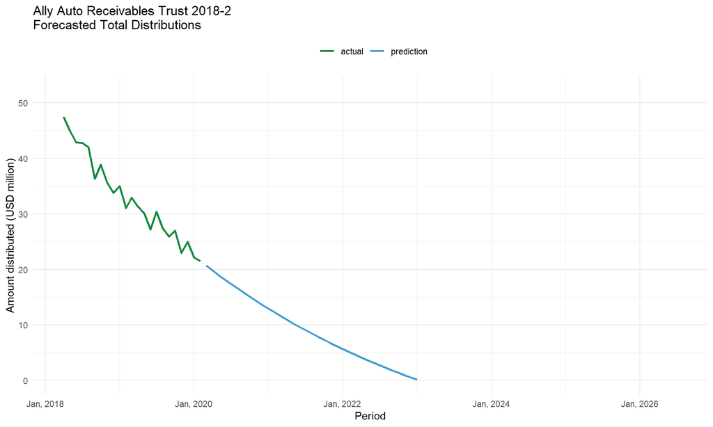

#### Ally Auto Receivables Trust 2018-3

##### Summary

Ending number of receivables: 41,213

Remaining principal balance across all receivables: $452,429,443

##### Current Period Distribution

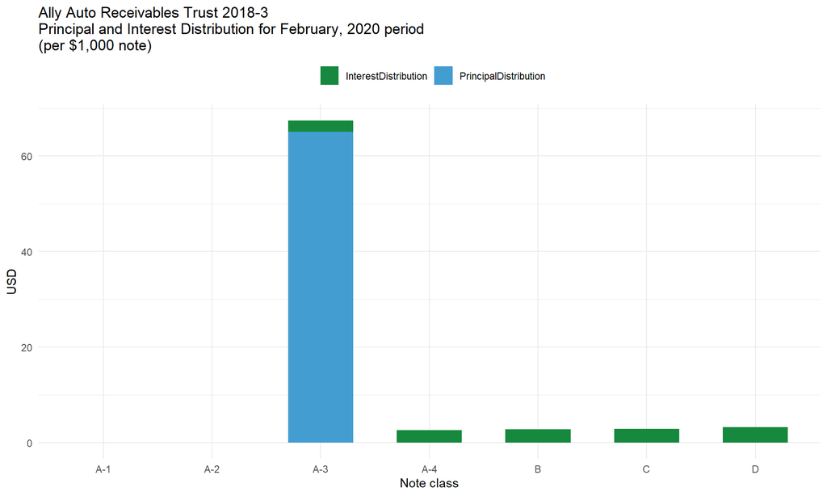

|  | deal | class | PrincipalDistribution | InterestDistribution |
| --- | --- | --- | --- | --- |
| 1 | Ally Auto Receivables Trust 2018-3 | A-1 | 0 | 0 |
| 2 | Ally Auto Receivables Trust 2018-3 | A-2 | 0 | 0 |
| 3 | Ally Auto Receivables Trust 2018-3 | A-3 | 65.1168771346705 | 2.3469412034384 |
| 4 | Ally Auto Receivables Trust 2018-3 | A-4 | 0 | 2.6 |
| 5 | Ally Auto Receivables Trust 2018-3 | B | 0 | 2.75833333333333 |
| 6 | Ally Auto Receivables Trust 2018-3 | C | 0 | 2.925 |
| 7 | Ally Auto Receivables Trust 2018-3 | D | 0 | 3.20833306255077 |

##### Cumulative Distribution

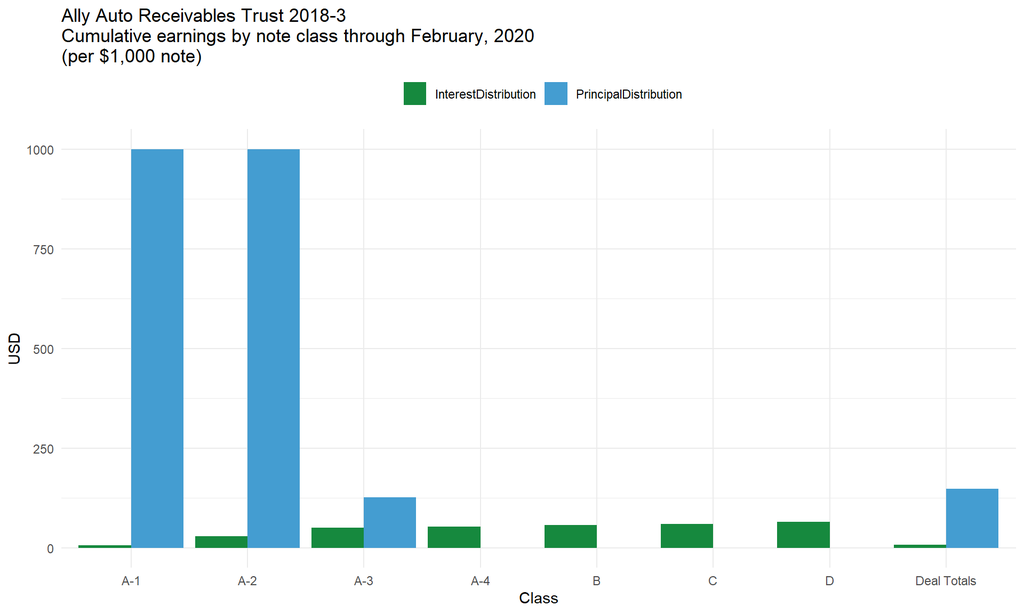

|  | deal | class | PrincipalDistribution | InterestDistribution |
| --- | --- | --- | --- | --- |
| 1 | Ally Auto Receivables Trust 2018-3 | A-1 | 1000 | 7.26379643109541 |
| 2 | Ally Auto Receivables Trust 2018-3 | A-2 | 1000 | 29.119455730659 |
| 3 | Ally Auto Receivables Trust 2018-3 | A-3 | 126.340401232092 | 51.3469412034384 |
| 4 | Ally Auto Receivables Trust 2018-3 | A-4 | 0 | 53.56 |
| 5 | Ally Auto Receivables Trust 2018-3 | B | 0 | 56.8216666666667 |
| 6 | Ally Auto Receivables Trust 2018-3 | C | 0 | 60.255 |
| 7 | Ally Auto Receivables Trust 2018-3 | D | 0 | 66.0916612510154 |

##### Forecast

Forecasted principal balances are based on a forecasted total amount distributed to interest and principal balances in future terms. These values are calculated using an ETS time series forecasting model. It uses the historic values as input to create the forecasted values (see bottom chart).

Remaining note principal balances are calculated in each period by subtracting the forecasted dsitribution amount from remaining note principal balances according to note seniority. In each period, the interest distribution amount is first calculated and subtracted from the forecasted distribution amount before applying the remaining distribution amount to the note principal balances for the next period.

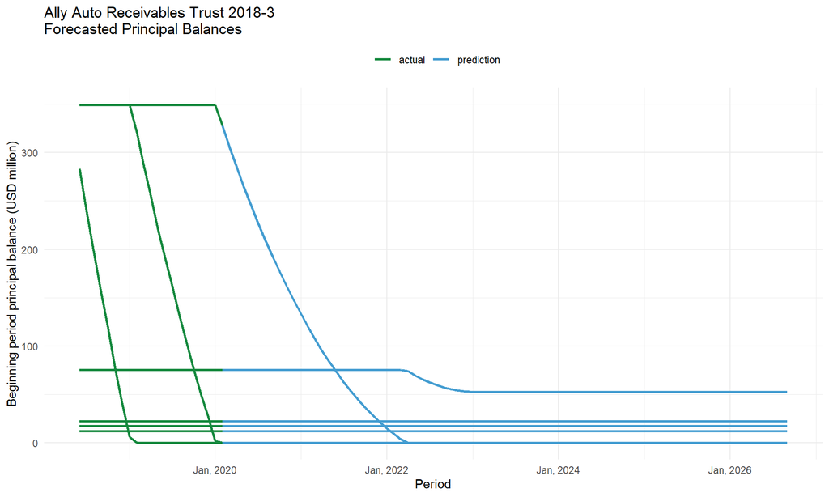

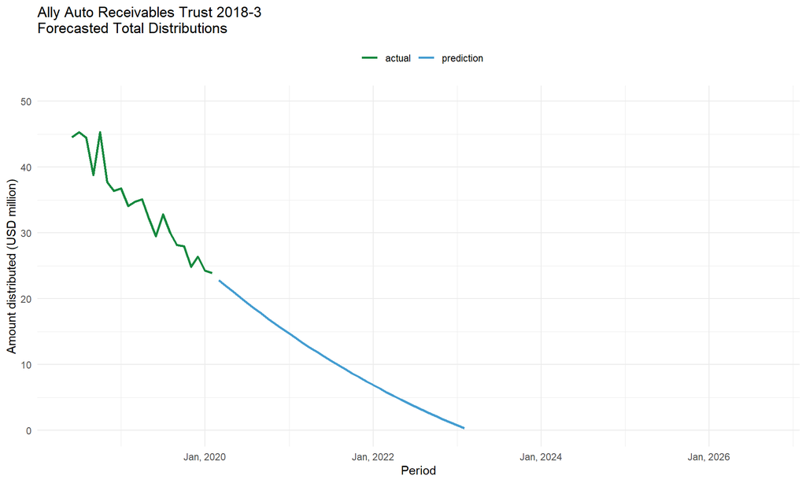